# Assignment 8 - Comparing Two Means

Your Name Here and ID number here

EPIB 607, Fall 2018, McGill University

2018-11-23

# 1 Food counseling for obese children (40 Points)

**a. Plot the data.** **(5 Points)**

(3 points) for the use of an appropriate plot to represent data

(2 points) for including figure caption, title, axis labels, units and legend (ie: control vs. intervention)

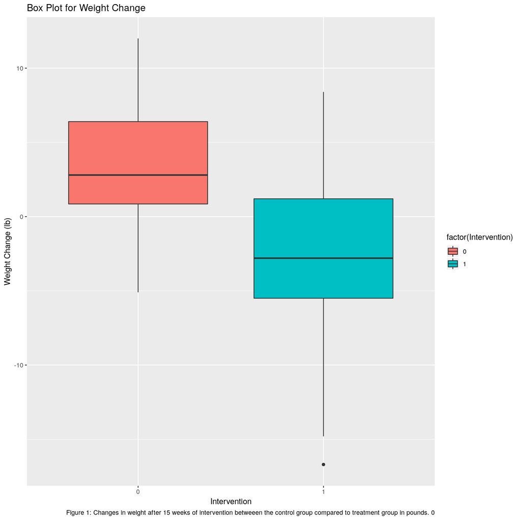

**b. We are interested in knowing if obese children receiving food counseling gain less weight over a 15-week period. State the regression model as a function of population parameters. Be sure to define what each parameter represents.** **(10 Points)**

(5 Points) for the regression model

$\mu = \mu_0 + \Delta\mu*\textrm{Intervention}$

where

$$\textrm{Intervention} = \begin{cases}
1 & \textrm{intervention group} \\
0 & \textrm{control group} \\
\end{cases}$$

(5 Points) for defining each parameter

$\mu$: The mean weight change over the 15 week period for the population in pounds.

$\mu_0$: The intercept; the mean weight change for the control group (When X = 0) in pounds.

$\Delta\mu$: The slope term; the population difference in mean weight change between control group and intervention group.

**c. Use a regression procedure to answer this question. State the hypotheses, interpret the parameter of interest and a brief statement about your findings. (20 Points)**

(5 Points) for hypotheses

$H_0: \mu_C = \mu_I$ The mean weight gain in control group equal to the mean weight gain in intervention group over the 15 week period.

$H_A: \mu_C \neq \mu_I$ The mean weight gain in control group is different from the mean weight gain in intervention group over the 15 week period.

(5 Points) for regression analysis

```r
obeselm <- lm(Weight ~ Intervention, data = obese) # (5 Points)
(sumobe <- summary(obeselm))
```

```
##
## Call:
## lm(formula = Weight ~ Intervention, data = obese)
##
## Residuals:
##      Min       1Q   Median       3Q      Max
## -14.2962  -2.8533  -0.6783   3.6038  10.8038
##
## Coefficients:
##              Estimate Std. Error t value Pr(>|t|)
## (Intercept)     3.478      1.039   3.348  0.00128 **
## Intervention   -5.882      1.244  -4.728 1.06e-05 ***
## ---
## Signif. codes:  0 '***' 0.001 '**' 0.01 '*' 0.05 '.' 0.1 ' ' 1
##
## Residual standard error: 4.983 on 74 degrees of freedom
## Multiple R-squared:  0.232,  Adjusted R-squared:  0.2216
## F-statistic: 22.35 on 1 and 74 DF,  p-value: 1.058e-05
```

(5 Points) for Interpretation of parameters:

$\hat\mu_0$: The estimated mean weight change of obese children assigned to the control group after 15 weeks is 3.478 lb.

$\hat\Delta\mu$: The estimated difference in mean weight change of obese children assigned to the intervention group compared to the control group is -5.882 lb.

(5 Points) for the conclusion/ statement :

```r
coef(sumobe)[2] + qnorm(c(0.025, 0.975)) * sqrt(vcov(sumobe)[2,2])
```

```
## [1] -8.320492 -3.443577
```

The estimated difference in mean weight change of obese children assigned to intervention group compared to the control group is -5.882 lb, 95% CI: [-8.32, -3.44] lb, with a p-value < 0.05. Because the p-value is lower than critical p-value and 95% CI does not capture zero in it, I conclude that the expected mean weight gain for control group is significantly different from the expected mean weight gain for the intervention group and reject the null hypothesis that $H_0: \mu_C = \mu_I$ in favor of $H_A$.

**d. Show how the Std. Error was calculated for the parameter of interest. (5 Points)**

SE for $\Delta\mu$: $SE_{\Delta\mu} = \sqrt{\frac{(N_{c} - 1)s_{c}^2 + (N_{I} - 1)s_{I}^2}{N_{c} + N_{I} - 2}} \sqrt{\frac{1}{N_{c}} + \frac{1}{N_{I}}}$

```r
Control <- obese[which(obese$Intervention == 0),]
Intervention <- obese[which(obese$Intervention == 1),]

SD_Control <- sd(Control$Weight)
SD_Intervention <- sd(Intervention$Weight)

N_Control <- nrow(Control)
N_Intervention <- nrow(Intervention)

SEM <- round(sqrt(((N_Control - 1)*(SD_Control^2) + (N_Intervention - 1)*(SD_Intervention^2))/(N_Control + N_Intervention - 2)) * sqrt(1/N_Control + 1/N_Intervention),3)
```

$N_{c}$ = 23

$N_{I}$ = 53

$s_{c}$ = 4.306

$s_{0}$ = 5.243

$SE_{\hat\Delta\mu} = \sqrt{\frac{(53 - 1)*5.24^2 + (23 - 1)*4.31^2}{53 + 23 - 2}} \sqrt{\frac{1}{53} + \frac{1}{23}}$

$SE_{\hat\Delta\mu}$ = 1.244. Std.Error from regression is the same as $SE_{\hat\Delta\mu}$ above and was calculated as indicated above.

# 2 Student drinking (20 Points)

**a. Do a complete analysis that reports on a comparison of the drinking behavior of women and men. (15 Points)**

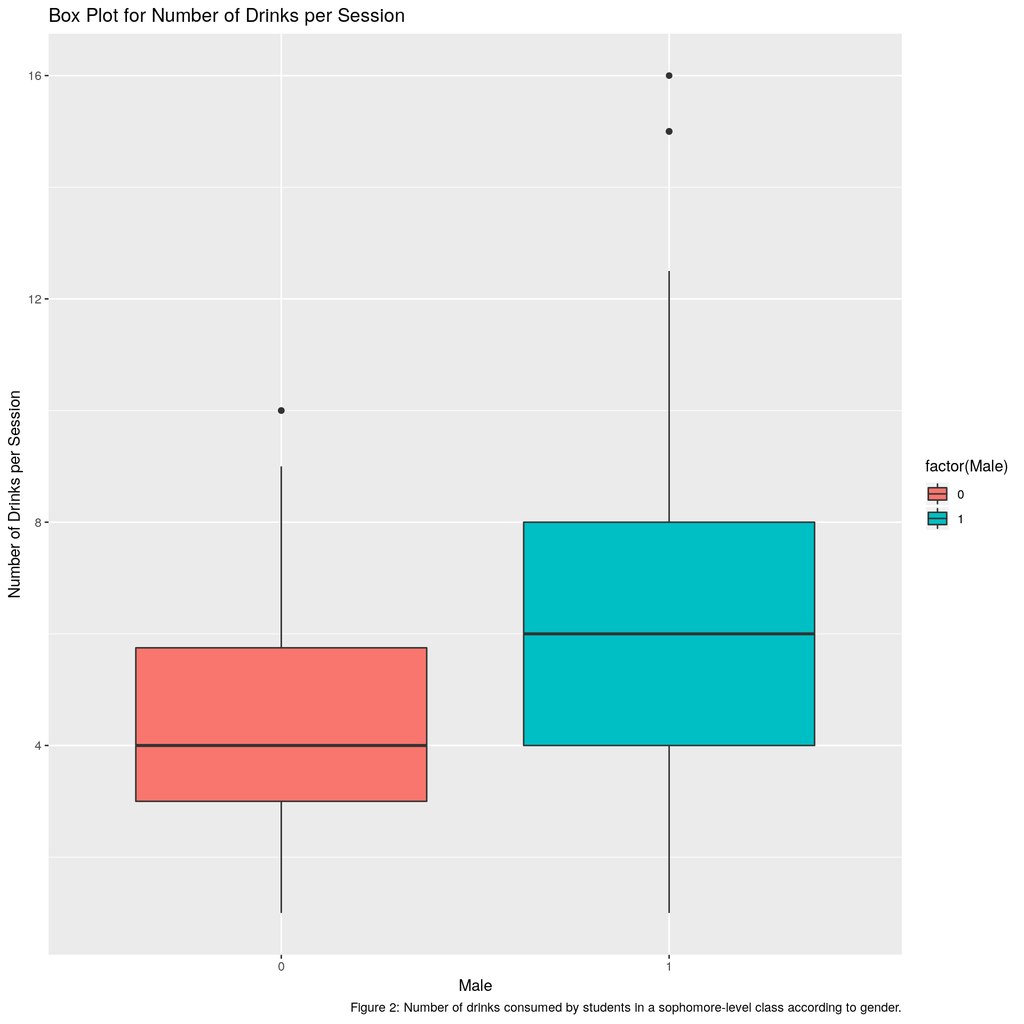

(2 Points) for the hypotheses:

$H_0: \mu_f = \mu_m$ The population mean number of drinks consumed by female students per session is equal to the mean number of drinks consumed by male students per session.

$H_A: \mu_f \neq \mu_m$ The population mean number of drinks consumed by female students per session is different from the mean number of drinks consumed by male students per session.

(5 Points) for the regression model:

$\mu = \mu_0 + \Delta\mu*Male$

where $\mu$ is the population mean number of drinks, $\mu_0$ is the population mean number of drinks for females and $\Delta\mu$ is the population mean difference in the number of drinks between males and females and

$$\textrm{Male} = \begin{cases}
1 & \textrm{male} \\
0 & \textrm{female} \\
\end{cases}$$

(4 Points) for R code, with summary function

```r
drinklm <- lm(Drinks~Male, data = drink) # (4 Points)
summary(drinklm)
```

```
##
## Call:
## lm(formula = Drinks ~ Male, data = drink)
##
## Residuals:
##     Min      1Q  Median      3Q     Max
## -5.5185 -1.7947 -0.2947  1.4815  9.4815
##
## Coefficients:
##             Estimate Std. Error t value Pr(>|t|)
## (Intercept)   4.2947     0.2837  15.138  < 2e-16 ***
## Male          2.2238     0.4182   5.318  3.2e-07 ***
## ---
## Signif. codes:  0 '***' 0.001 '**' 0.01 '*' 0.05 '.' 0.1 ' ' 1
##
## Residual standard error: 2.765 on 174 degrees of freedom
## Multiple R-squared:  0.1398, Adjusted R-squared:  0.1348
## F-statistic: 28.28 on 1 and 174 DF,  p-value: 3.197e-07
```

```r
coef(drinklm)[2] + qnorm(c(0.025, 0.975)) * sqrt(vcov(drinklm)[2,2])
```

```
## [1] 1.404133 3.043431
```

(4 Points) for the interpretation of parameters:

$\hat\mu_0$: The estimated mean number of drinks for female students per session is 4.29.

$\hat\Delta\mu$: The estimated difference in mean number of drinks between female and male students per session is 2.22 [1.40, 3.04].

**b. Summarise your findings in a 140 character tweet. (5 Points)**

A new study finds a significant difference between male and female drinking behavior among sophomore students! Male students have around 2 to 3 more drinks compared to females.

**c. Verify the constant variance assumption of your model.(BONUS 5 Points)**

(1 Points) for the method used to get to the conclusion - R Code

```
## Non-constant Variance Score Test
## Variance formula: ~ fitted.values
## Chisquare = 16.12991, Df = 1, p = 5.9143e-05
```

```
## Levene's Test for Homogeneity of Variance (center = median)
##        Df F value    Pr(>F)
## group   1  12.961 0.0004145 ***
##       174
## ---
## Signif. codes:  0 '***' 0.001 '**' 0.01 '*' 0.05 '.' 0.1 ' ' 1
```

```
##
##  Bartlett test of homogeneity of variances
##
## data:  Drinks by as.factor(Male)
## Bartlett's K-squared = 16.716, df = 1, p-value = 4.34e-05
```

(4 Points) for Explanation:

Any of the three equality of variance tests (non-constant variance score test, Levene, and Bartlett) have p-values less than critical p-value 0.05. This leads us to reject the null hypothesis that was tested here which states that the variance in the number of drinks is equal for males and females.

# 3 Ink toxicity (40 Points)

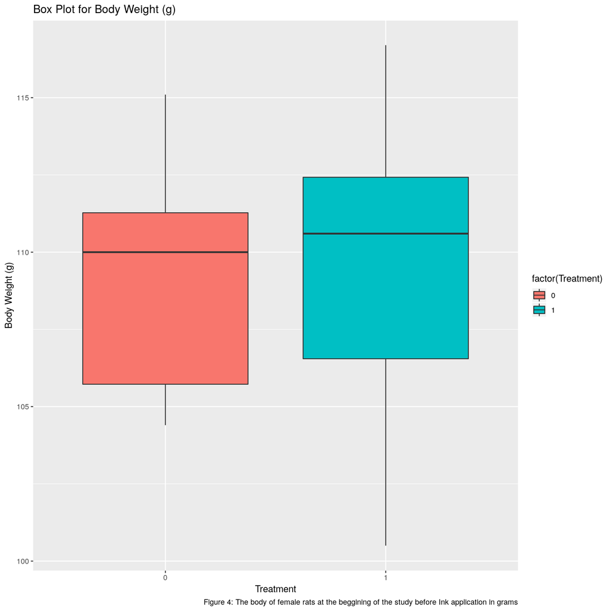

**a. Verify that the two experimental groups are not significantly different at the beginning of the study (10 Points)**

(2 Points) Hypotheses:

$H_0: \mu_0 = \mu_1$ The mean body weight of female rats in the control group is equal to the mean body weight of female rats in the treatment group at the begining of the study.

$H_A: \mu_0 \neq \mu_1$ The mean body weight of female rats in the control group is not equal to the mean body weight of female rats in the treatment group at the begining of the study.

(2 Points) for the regression model:

**$\mu = \mu_0 + \Delta\mu*Treatment$**

where $\mu$ is the population mean weight of rats at the start of the study, $\mu_0$ is the population mean weight of the control rat at the start of the study, $\Delta \mu$ is how much more (or less) the treatment (ie: ink) rats weigh at the start of the study compared to the control rats, and $Treatment$ is the dummy variable where when a rat is given the ink, Treatment = 1 and when control Treatment = 0.

(2 Points) for the method of testing (Regression (Or t.test)

```r
Inkbeforelm <- lm(Week0 ~ Treatment, data = Ink)
summary(Inkbeforelm)
```

```
##
## Call:
## lm(formula = Week0 ~ Treatment, data = Ink)
##
## Residuals:
##    Min     1Q Median     3Q    Max
## -8.830 -3.335  1.270  2.945  7.370
##
## Coefficients:
##             Estimate Std. Error t value Pr(>|t|)
## (Intercept)  109.310      1.386   78.84   <2e-16 ***
## Treatment      0.020      1.961    0.01    0.992
## ---
## Signif. codes:  0 '***' 0.001 '**' 0.01 '*' 0.05 '.' 0.1 ' ' 1
##
## Residual standard error: 4.384 on 18 degrees of freedom
## Multiple R-squared:  5.78e-06,   Adjusted R-squared:  -0.05555
## F-statistic: 0.000104 on 1 and 18 DF,  p-value: 0.992
```

```r
coef(Inkbeforelm)[2] + qt(c(0.025, 0.975), df = nrow(Ink) - 1) * sqrt(vcov(Inkbeforelm)[2,2])
```

```
## [1] -4.083786  4.123786
```

(4 Points) Conclusion with evidence:

The expected mean difference in body weight of female rats between the control and treatment groups at the begging of the study is 0.020 [-4.08, 4.12] grams with a p-value of 0.992. Therefore, the two experimental groups are not significantly different at the beginning of the study.

**b. Is there good evidence that ink application impairs growth in female rats between 7 and 20 weeks of age? State your answer in terms of the % difference between the mean weight gains of the two populations. Provide a 95% confidence interval for the % difference between the mean weight gains of the two populations.(20 Points)**

(4 Points) Hypotheses:

The parameter of interest is $\theta = \frac{\mu_1}{\mu_0}$, i.e., the ratio of mean weight gain of rats in the treatment group ($\mu_1$) compared to the control group ($\mu_0$).

$H_0: \theta = 1$ The ratio between the mean body weight gain of female rats in the treatment and control groups is equal to 1.

$H_A: \theta \neq 1$ The ratio between the mean body weight gain of female rats in the treatment and control groups is not equal to 1.

**OR**

$H_0: \% Difference = 0$ The % difference between the mean weigh gains of the treatment and control groups is equal to zero.

$H_A: \% Difference \neq 0$ The % difference between the mean weigh gains of the treatment and control groups is not equal to zero.

(4 Points) for the regression model:

The regression model is:

$$\mu = \mu_0 * \theta^{\textrm{Treatment}}$$

Since we cannot fit this model using a regression routine, we take the log of both sides:

$$\log(\mu) = \log(\mu_0) + log(\theta)\cdot \textrm{Treatment}$$

(8 Points) for the method of testing (Regression)

```r
Ink$Diff <- Ink$Week13 - Ink$Week0
Inkafterglm <- glm(Diff~Treatment, data = Ink, family = gaussian(link = "log")) # (4 Points)
summaryInk <- summary(Inkafterglm)
summaryInk
```

```
##
## Call:
## glm(formula = Diff ~ Treatment, family = gaussian(link = "log"),
##     data = Ink)
##
## Deviance Residuals:
##     Min       1Q   Median       3Q      Max
## -10.920   -4.965   -1.260    3.635   14.580
##
## Coefficients:
##             Estimate Std. Error t value Pr(>|t|)
## (Intercept)  4.44641    0.02704 164.426  < 2e-16 ***
## Treatment   -0.14370    0.04130  -3.479  0.00268 **
## ---
## Signif. codes:  0 '***' 0.001 '**' 0.01 '*' 0.05 '.' 0.1 ' ' 1
##
## (Dispersion parameter for gaussian family taken to be 53.23311)
##
##     Null deviance: 1610.3  on 19  degrees of freedom
## Residual deviance:  958.2  on 18  degrees of freedom
## AIC: 140.14
##
## Number of Fisher Scoring iterations: 4
```

```r
theta <- exp(coef(summaryInk)[2])
Diff <- (theta - 1)*100

#95%CIscoef (4 Points)
CIs_log_theta <- coef(summaryInk)[2] + qt(p = c(0.025, 0.975), df = nrow(Ink)-2) *  sqrt(vcov(summaryInk)[2,2])

CIs_theta <- exp(CIs_log_theta)
CIs_Diff <- (CIs_theta - 1)*100

#OR

coeff <- exp(confint(Inkafterglm))
CIs_con_theta <- c(coeff[2],coeff[4])
CIs_con_Diff <- (CIs_con_theta - 1)*100
```

$\theta = \frac{\mu_1}{\mu_0}$

$\% Difference = \frac{\mu_1 - \mu_0}{\mu_0}= \frac{\mu_1}{\mu_0} - \frac{\mu_0}{\mu_0}= \frac{\mu_1}{\mu_0} - 1= \theta - 1$

$\log\theta = Estimate = -0.144$

$\theta = 0.866$

$\% Difference = (0.866 - 1)*100\%$

$\% Difference =$ -13.3849039

(4 Points) Conclusion:

The % difference in the mean weight gain between the treatment group and the control group is -13.4%. The 95% CIs for the % difference in mean weight gain is [-20.2, -6.11]%. The 95% CIs do not capture zero and therefore, we can reject the null hypothesis that there is no difference in the mean weight gain between control and treatment group.

**c. Show how the p-value in the glm output was calculated for the parameter of interest. (10 Points)**

P-value for $\log\hat{\theta}$:

1. Point estimate for $\log\hat{\theta} =$ -0.1437
2. SE for $\log\hat{\theta}$: $SE_{\log\hat{\theta}} =$ 0.0413
3. degree of freedom: $df = n_1 + n_0 - 2 = 10 + 10 -2 = 18$
4. 2-sided t statistic: $t = \frac{\log\hat{\theta} - 0}{SE_{\log\hat{\theta}}} = \frac{{-0.144} - 0}{0.041}=$ -3.479;
5. p-value for $\log\hat\theta$: $p = Pr(>|t|) = pt(q = -3.479, df = 18) * 2 =$ 0.00268.

# Code

```r
## ---- Setup ------------------------------------------------------------------
setwd("~/git_repositories/epib607/assignments/a8/")
knitr::opts_chunk$set(
  echo = FALSE,          # don't show code
  warning = FALSE,       # don't show warnings
  message = FALSE,       # don't show messages (less serious warnings)
  cache = FALSE,         # set to TRUE to save results from last compilation
  fig.align = "center",   # center figures
  fig.asp = 1,          # fig.aspect ratio
  fig.width = 10        # fig width
)
obese <- read.csv("obese.csv",header = TRUE)

library(mosaic)
library(ggplot2)
library(dplyr)

ObesePlot <- ggplot(obese, aes(x = factor(Intervention), y = Weight)) +
  geom_boxplot(aes(fill=factor(Intervention)))
ObesePlot +
  xlab("Intervention") +
  labs(title = "Box Plot for Weight Change" ,
       caption = "Figure 1: Changes in weight after 15 weeks of intervention betweeen the control group compared to treatment group in pounds. 0", y = "Weight Change (lb)")

obeselm <- lm(Weight ~ Intervention, data = obese) # (5 Points)
(sumobe <- summary(obeselm))
coef(sumobe)[2] + qnorm(c(0.025, 0.975)) * sqrt(vcov(sumobe)[2,2])
Control <- obese[which(obese$Intervention == 0),]
Intervention <- obese[which(obese$Intervention == 1),]

SD_Control <- sd(Control$Weight)
SD_Intervention <- sd(Intervention$Weight)

N_Control <- nrow(Control)
N_Intervention <- nrow(Intervention)

SEM <- round(sqrt(((N_Control - 1)*(SD_Control^2) + (N_Intervention - 1)*(SD_Intervention^2))/(N_Control + N_Intervention - 2)) * sqrt(1/N_Control + 1/N_Intervention),3)

drink <- read.csv("drinking.csv",header = T)

DrinkPlot <- ggplot(drink, aes(x = factor(Male), y = Drinks)) +
  geom_boxplot(aes(fill = factor(Male)))
DrinkPlot +
  xlab("Male") +
  labs(title = "Box Plot for Number of Drinks per Session" , caption = "Figure 2: Number of drinks consumed by students in a sophomore-level class according to gender.", y = "Number of Drinks per Session")

drinklm <- lm(Drinks~Male, data = drink) # (4 Points)
summary(drinklm)
coef(drinklm)[2] + qnorm(c(0.025, 0.975)) * sqrt(vcov(drinklm)[2,2])
pacman::p_load(car)
car::ncvTest(drinklm)
car::leveneTest(Drinks~as.factor(Male), data = drink)
stats::bartlett.test(Drinks~as.factor(Male), data = drink)
Ink <- read.csv("Ink.csv",header = T)

InkPlot <- ggplot(Ink, aes(x = factor(Treatment), y = Week0)) +
  geom_boxplot(aes(fill = factor(Treatment)))
InkPlot +
  xlab("Treatment") +
  labs(title = "Box Plot for Body Weight (g)" , caption = "Figure 4: The body of female rats at the beggining of the study before Ink application in grams", y = "Body Weight (g)")

Inkbeforelm <- lm(Week0 ~ Treatment, data = Ink)
summary(Inkbeforelm)
coef(Inkbeforelm)[2] + qt(c(0.025, 0.975), df = nrow(Ink) - 1) * sqrt(vcov(Inkbeforelm)[2,2])
Ink$Diff <- Ink$Week13 - Ink$Week0
Inkafterglm <- glm(Diff~Treatment, data = Ink, family = gaussian(link = "log")) # (4 Points)
summaryInk <- summary(Inkafterglm)
summaryInk

theta <- exp(coef(summaryInk)[2])
Diff <- (theta - 1)*100

#95%CIscoef (4 Points)
CIs_log_theta <- coef(summaryInk)[2] + qt(p = c(0.025, 0.975), df = nrow(Ink)-2) *  sqrt(vcov(summaryInk)[2,2])

CIs_theta <- exp(CIs_log_theta)
CIs_Diff <- (CIs_theta - 1)*100

#OR

coeff <- exp(confint(Inkafterglm))
CIs_con_theta <- c(coeff[2],coeff[4])
CIs_con_Diff <- (CIs_con_theta - 1)*100

point_estimate <- round(summaryInk$coefficients[2],5)
SE <- round(summaryInk$coefficients[4],5)
df <- summaryInk$df.residual
t_statistic <- round(((point_estimate - 0) / SE),3)
p_value <- round((pt(q = t_statistic, df = df) * 2),5)
```